# Pot Survey – May 2023

May 1 - 3, 2023 *F/V Integrity* West Ocean City, MD

Author

Mike O’Brien (UMCES)

[interactive chart not shown]

## Packing list

🔲 Large cooler

🔲 Sampling bags and bag tags

🔲 Data sheets/clipboard

🔲 >2 fish pots

🔲 Two kill buckets

🔲 GPS

🔲 HOBO loggers (2)

🔲 MS222

🔲 Measuring board

🔲 Weight bucket with scales

🔲 2 fish totes

## Participants

### May 1-3

- Mike O’Brien: 267-970-1973
- Lauren Rodriguez: 586-904-1264

### May 2-3

- Mike O’Brien
- Lauren Rodriguez
- Capt. Brandon Harrington
- *Integrity* mate

## Schedule

### 1 May

Scientific crew (MOB, LR)

- 0800 - 0900 MOB pack CBL truck (2017 Silverado) at Solomons, MD. Drive to Harry S Truman Park and Ride.
  - 200 Harry S. Truman Pkwy, Annapolis, MD 21401
- 1015 - 1230 MOB picks up LR. Drive to MD Coastal Bays Program office.
  - 8219 Stephen Decatur Hwy, Berlin, MD 21811
- 1230 - 1250 Load pots and two rope drums onto trailer.
- 1250 - 1300 Drive to Sea Born LLC.
  - 12906 Sunset Ave, Ocean City, MD 21842

Full crew (MOB, LR, BH, mate)

- 1300 - 1330 Unload pots. KH/mate begin loading pots onto vessel.
- 1330 - 1530 DHS/MOB drive to MD Coastal Bays Program. Repeat pot loading/return/unloading.
- 1530 - 1600 Drop trailer off at MDCBP. Return to W Ocean City.
- 1600 - 1800 Finish rigging ground line.
- 1800 Check into Microtel
  - 12536 Ocean Gateway, Ocean City, MD 21842

### May 02

Scientific & Sea Born crew

- 02:30 Meet at *F/V Integrity*
- 03:00 Depart OCMD for **K09**
- **38 19.1773, -74 42.4767**
- 05:20 Arrive **K09**. Deploy pots.
- 05:30 Finish deploying pots. Depart for **K12**
- **38 16.1415, -74 42.9659**
- 05:55 Arrive **K12**. Deploy pots.
- 06:05 Finish deploying pots. Depart for **L12**
- **38 16.1392, -74 41.9887**
- 06:15 Arrive **L12**. Deploy pots.
- 06:25 Finish deploying pots. Depart for **M12**
- **38 16.1367, -74 41.0115**
- 06:35 Arrive **M12**. Deploy pots.
- 06:45 Finish deploying pots. Depart for **C2305-2**
- **38 12.3453, -74 39.2436**
- 07:20 Arrive **C2305-2**. Deploy pots.
- 07:30 Finish deploying pots. Depart for **C2305-1**
- **38 11.6843, -74 44.3577**
- 08:05 Arrive **C2305-1**. Deploy pots.
- 08:15 Finish deploying pots. Depart for **OCMD**
- 10:40 Arrive **OCMD**

Scientific crew picks up dry ice from Harris Teeter

- 31221 Americana Pkwy, Selbyville, DE 19975

### May 03

Scientific & Sea Born crew

- 02:30 Meet at *F/V Integrity*
- 03:00 Depart OCMD for **K09**
- 05:20 Arrive **K09**. Deploy pots.
- 05:35 Finish deploying pots. Depart for **K12**
- 06:00 Arrive **K12**. Deploy pots.
- 06:15 Finish deploying pots. Depart for **L12**
- 06:25 Arrive **L12**. Deploy pots.
- 06:40 Finish deploying pots. Depart for **M12**
- 06:50 Arrive **M12**. Deploy pots.
- 07:05 Finish deploying pots. Depart for **C2305-2**
- 07:40 Arrive **C2305-2**. Deploy pots.
- 07:55 Finish deploying pots. Depart for **C2305-1**
- 08:30 Arrive **C2305-1**. Deploy pots.
- 08:45 Finish deploying pots. Depart for **OCMD**
- 11:10 Arrive **OCMD**
- 11:30 Pick up trailer from MD Coastal Bays Program
- 11:45 Remove pots from F/V Integrity, load onto trailer. Unload at MD Coastal Bays program. Repeat as needed.

13:10 Scientific crew drive back to Solomons, MD

## Distances

Distance, nautical miles

|  | OCMD | C2305-1 | C2305-2 | K09 | L12 | M12 | K12 |
| --- | --- | --- | --- | --- | --- | --- | --- |
| OCMD | 0.00 | 18.92 | 22.40 | 18.63 | 19.33 | 20.09 | 18.58 |
| C2305-1 | 18.92 | 0.00 | 4.08 | 7.64 | 4.83 | 5.17 | 4.59 |
| C2305-2 | 22.40 | 4.08 | 0.00 | 7.29 | 4.37 | 4.04 | 4.79 |
| K09 | 18.63 | 7.64 | 7.29 | 0.00 | 3.06 | 3.25 | 3.06 |
| L12 | 19.33 | 4.83 | 4.37 | 3.06 | 0.00 | 0.77 | 0.77 |
| M12 | 20.09 | 5.17 | 4.04 | 3.25 | 0.77 | 0.00 | 1.54 |
| K12 | 18.58 | 4.59 | 4.79 | 3.06 | 0.77 | 1.54 | 0.00 |

Distance, time at 8 kts

|  | OCMD | C2305-1 | C2305-2 | K09 | L12 | M12 | K12 |
| --- | --- | --- | --- | --- | --- | --- | --- |
| OCMD | - | 02 h 25 m | 02 h 50 m | 02 h 20 m | 02 h 25 m | 02 h 35 m | 02 h 20 m |
| C2305-1 | 02 h 25 m | - | 00 h 35 m | 01 h 00 m | 00 h 40 m | 00 h 40 m | 00 h 35 m |
| C2305-2 | 02 h 50 m | 00 h 35 m | - | 00 h 55 m | 00 h 35 m | 00 h 35 m | 00 h 40 m |
| K09 | 02 h 20 m | 01 h 00 m | 00 h 55 m | - | 00 h 25 m | 00 h 25 m | 00 h 25 m |
| L12 | 02 h 25 m | 00 h 40 m | 00 h 35 m | 00 h 25 m | - | 00 h 10 m | 00 h 10 m |
| M12 | 02 h 35 m | 00 h 40 m | 00 h 35 m | 00 h 25 m | 00 h 10 m | - | 00 h 15 m |
| K12 | 02 h 20 m | 00 h 35 m | 00 h 40 m | 00 h 25 m | 00 h 10 m | 00 h 15 m | - |

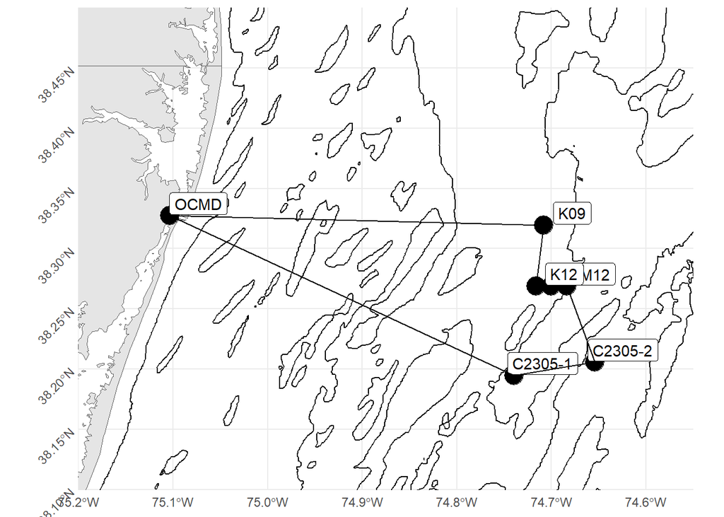